# Автоматическое определение слоговой структуры в славянских языках на основании словарных данных. Autimatic Syllable Structure Extracting from Dictionaries: Slavic Data

Выпускная квалификационная работа Ксения Романова, БКЛ153 Научный руководитель: Г. А. Мороз

17 июня 2019

## Введение

- описание слоговой структуры македонского, польского, русского
  - построение модели слоговой структуры для каждого языка
- (полу-)автоматизация
- использование большого массива данных для построения и проверки модели

## Обзор языков

Indo-European > Balto-Slavic > Slavic >

- South Slavic > Eastern South Slavic > Macedo-Bulgarian > Macedonian
- West Slavic > Lechitic > Polish
- East Slavic > Russian

(Hammarström, Haspelmath, and Forkel 2019)

# Македонский язык

## Фонетическая система: согласные

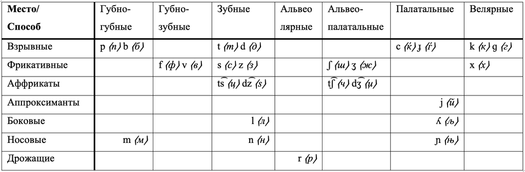

*таблица 1. Консонантная система македонского языка*

по (Friedman 2002), (Усикова 2003)

## Фонетическая система: гласные

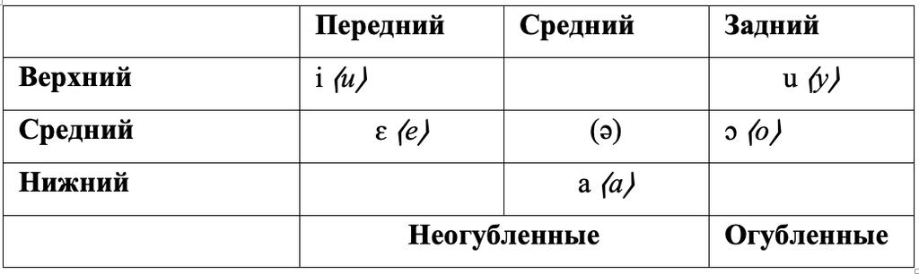

*таблица 2. Вокалическая система македонского языка*

по (Friedman 2002), (Усикова 2003)

# Польский язык

## Фонетическая система: согласные

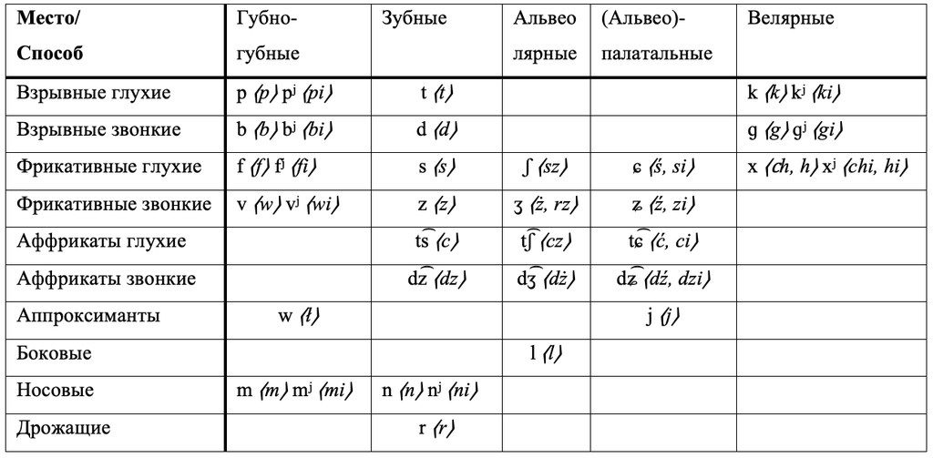

*таблица 3. Консонантная система польского языка*

по (Feldstein 2001)

## Фонетическая система: гласные

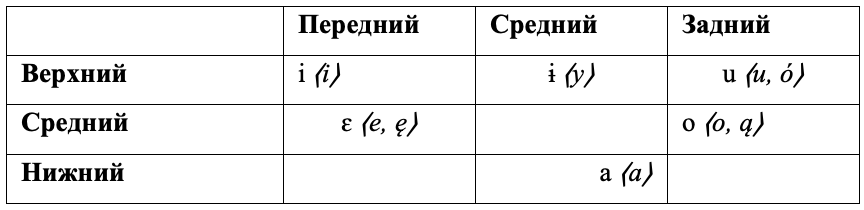

*таблица 4. Вокалическая система польского языка*

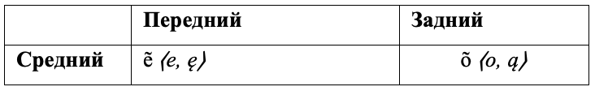

*таблица 5. Вокалическая система польского языка: носовые*

по (Feldstein 2001)

# Русский язык

## Фонетическая система: согласные

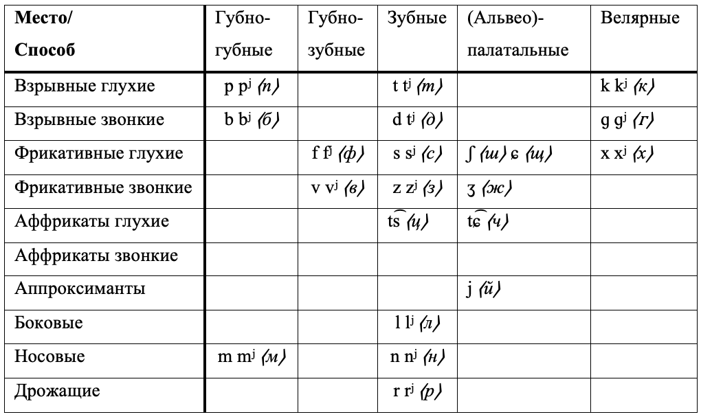

*таблица 6. Консонантная система русского языка*

по (Andrews 2001), (Timberlake 1993), (Timberlake 2004)

## Фонетическая система: гласные

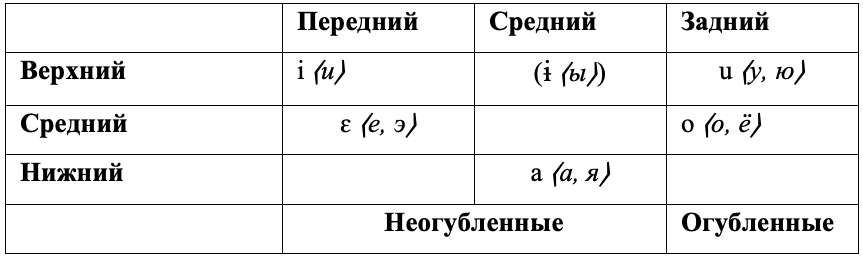

*таблица 7. Вокалическая система русского языка*

по (Andrews 2001), (Timberlake 1993), (Timberlake 2004)

## Описание фонотактической структуры (1)

инициаль — ядро — финаль

- инициаль — согласные, предшествующие ядру
- финаль — согласные, следующие за ядром
- ядро — вершина слога

## Описание фонотактической структуры (2):

Теория сонорности (Clements 1990) предсказывает распределение разных типов сегментов относительно ядра

Иерархия сонорности (Wright and others 2004):

бо́льшая звучность - - - - - - - - - - - - - - - - - - - меньшая звучность

гласные > глайды > плавные > носовые > фрикативные > взрывные

## Кластеры и слоги

*простые* vs *сложные* (Maddieson 2009)

**C** — *cosonant* согласный, **V** — *vowel* гласный, в скобках — опциональных элементы

- простые: *(C)V(V)*
  - например, гавайский язык (австронезийская семья) (Maddieson 2013)
- сложные: *(C)(C)(C)V(C)(C)*
  - например, адыгейский (абхазо-адыгская семья) (Мороз 2019)

## Методы определения принципов слогоделения

- элицитация (Duanmu 2009)
- эксперименты (Côté and Kharlamov 2010)
- частичная автоматизация процесса (Czerniak 2015), (Мороз 2019)

## Интервокальные кластеры: волновой характер слога

Разные типы языков (Кодзасов and Муравьева 1980):

- “квантовые” языки
  - слог характеризуется пограничными сигналами, которые маркируют его границы
- “волновые” языки
  - границы слога не маркируются
  - ко-шка vs кош-ка (Князев 1999)

## Алгоритм по (Мороз 2019)

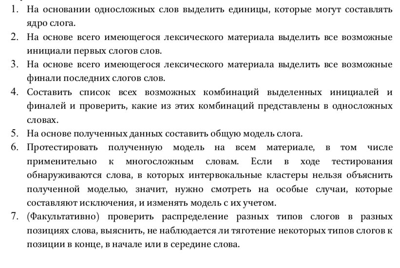

## Сбор данных: македонский язык

Для македонского языка было собрано и размечено 54 474 лексем из *Онлайн словаря македонского языка* (Дигитален речник на македонскиот јазик) (ДРМЈ)

Из рассмотрения были исключены: сокращения, аббревиатуры, сложные слова, междометия

В итоговой выборке 53 468 лексем

## Сбор данных: польский язык

Для польского языка обкачен *Грамматический словарь польского языка* (Słownik Gramatyczny Języka Polskiego) (SGJP)

Всего: 7 967 216 словоформ

Исключены: “бессложные слова” — *NKWD*, *TKKF*, *KGB*

В итоговой выборке: 7 967 118 словоформ

## Сбор данных: русский язык

Для русского языка данные собраные из подготовленного *Открытого грамматического словаря русского языка*:

- 102 375 лексем
- 4 596 304 словоформ

## Методология (1)

1. На основании грамматических описаний:
- для македонского (Friedman 2002), (Усикова 2003),
- для польского (Feldstein 2001),
- для русского (Andrews 2001), (Timberlake 1993), (Timberlake 2004)

и односложных слов выделены единицы, которые могут составлять ядро слога:

- гласные

для македонского языка:

- слоговые:
  - /r̩/ в начале слова перед согласным: *рж* [r̩ʒ];
  - /r̩/ в позиции между двумя согласными: *крв* [kr̩v];
  - /r̩/, /l̩/, /n̩/ в конце слова после согласного и в заимствованиях: *тембр* [tɛmbr̩], *сингл* [sinɡl̩], *њутн* [ɲutn̩]

## Методология (1.5)

Упрощение:

- **V** — *vocalic*
  - вершина слога
- **S** — *sonorant* сонорные
  - аппроксиманты **J**
  - вибранты **R**
  - боковые **L**
  - носовые **N**
- **O** — *obstruent* шумные
  - фрикативные, аффрикаты, взрывные

## Методология (2&3)

2&3. На основании собранного лексического материала выделить возможные абсолютные инициали и финали

## Методология (4)

4. Составить список возможных инициалей и финалей, составить список комбинаций:

[кластер конечный] + [кластер начальный]

например, **OS** *V* **SS** > **SS OS**

## Методология (4): пример

|  | intervocalic_all_quality |
| --- | --- |
| 1 | O |
| 2 | O-O |
| 3 | O-S |
| 4 | O-S-S |
| 5 | O-O-S |
| 6 | O-O-O |
| 7 | O-O-O-S |
| 8 | O-O-O-O |
| 9 | S |
| 10 | S-O |

[output cut: 158 more lines]

## Методология (5)

5. На основании полученных данных составить общую (первичную) модель слога

## Методология (5): македонский язык

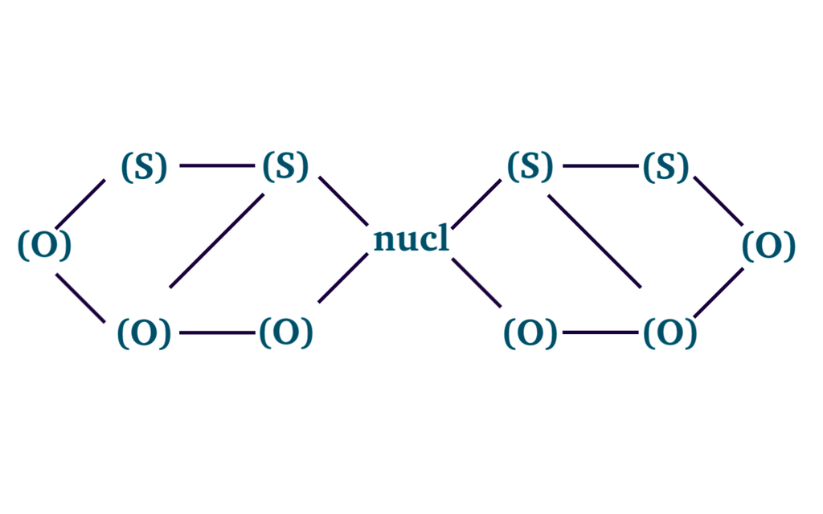

Модель 1. Модель слога македонского языка.

## Методология (5): русский язык

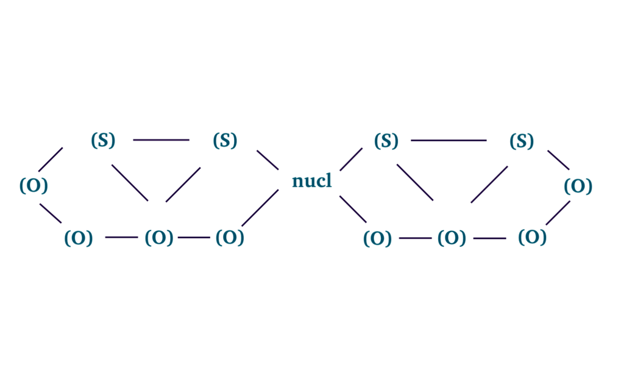

Модель 2. Модель слога русского языка.

## Методология (6.1)

6. Проверить первичную модель на выборке всех слов, (включая многосложные).

## Методология (6.1): пример

|  | not_predicted_intervocalic_monosyllabic_manner |
| --- | --- |
| 1 | R-R-O-O |

## Методология (6.2)

Если модель определит слова, с интервокальными кластерами, которые не будут предсказаны этой моделью,

нужно пересмотреть эти случаи и, при необходимости, скорректировать модель с учётом них

*андоррский*

## Перепорождение

|  | excess_clusters_intervocalic_all_quality |
| --- | --- |
| 1 | O-O-O-O-O-O |
| 2 | O-O-O-O-O-S |
| 3 | O-O-O-O-O-S-S |
| 4 | O-O-O-O-O-O-S |
| 5 | O-O-O-O-O-O-O |
| 6 | O-O-O-O-O-O-O-S |
| 7 | O-O-O-O-O-O-O-O |
| 8 | O-O-O-O-S-O |
| 9 | O-O-O-O-S-S |
| 10 | O-O-O-O-S-O-O |

[output cut: 121 more lines]

OOO-V-OOO,

OOO-V-SOO,

OOO-V-SSO,

OOS-V-OOO,

OOS-V-SOO,

OOS-V-SSO,

OSS-V-OOO,

OSS-V-SOO

OSS-V-SSO,

## Литература

Andrews, Edna. 2001. “The Russian Reference Grammar.” *Internet: Www. Seelrc. Org* 8080.

Clements, George N. 1990. “The Role of the Sonority Cycle in Core Syllabification.” *Papers in Laboratory Phonology* 1: 283–333.

Côté, Marie-Hélène, and Viktor Kharlamov. 2010. “The Impact of Experimental Tasks on Syllabification Judgments: A Case Study of Russian.” In *Handbook of the Syllable*, 271–94. Brill.

Czerniak, Tomasz. 2015. “Word-Initial Clusters in Welsh: A Typological Analysis.” *Young Minds Vs. Old Questions in Linguistics*, 29.

Duanmu, San. 2009. *Syllable Structure: The Limits of Variation*. Oxford University Press.

Feldstein, Ronald F. 2001. *A Concise Polish Grammar*. Slavic; East European Language Research Center (SEELRC), Duke University.

Friedman, Victor A. 2002. “Macedonian (Languages of the World/Materials 117).” *München: LINCOM Europa*.

Hammarström, H, M Haspelmath, and R Forkel. 2019. “Glottolog 3.3. About Languoids (2018).”

Maddieson, Ian. 2009. “Calculating Phonological Complexity.” *Approaches to Phonological Complexity*. Mouton de Gruyter Berlin, Germany, 85–110.

———. 2013. “Syllable Structure.” In *The World Atlas of Language Structures Online*, edited by Matthew S. Dryer and Martin Haspelmath. Leipzig: Max Planck Institute for Evolutionary Anthropology. https://wals.info/chapter/12.

Timberlake, Alan. 1993. “Russian.” *The Slavonic Languages* 827. London: Routledge: 886.

———. 2004. *A Reference Grammar of Russian*. Cambridge University Press.

Wright, Richard, and others. 2004. “A Review of Perceptual Cues and Cue Robustness.” *Phonetically Based Phonology*, 34–57.

Князев, С.В. 1999. “О критериях слогоделения в современном русском языке: Теория волны сонорности и теория оптимальности.” *Вопросы языкознания*, no. 1: 84–102.

Кодзасов, С.В., and И.А. Муравьева. 1980. “Слог и ритмика слова в алюторском языке.” *Публикации отделения структурной и прикладной лингвистики МГУ. Филологический факультет*, no. 9.

Мороз, Г.А. 2019. “Слоговая структура адыгейского языка: От данных к обобщениям.” *Вопросы языкознания*, no. 2: 82–95.

Усикова, Рина П. 2003. “Грамматика македонского литературного языка.” *М.: Муравей*.